# R语言基础

### 基本计算

在r语言计算中，优先级和正常数学运算一样，比如乘法优先级大于加减等等，下表列出了一些常见的进行运算的符号

| 符号 | 功能 | 例子 |
| --- | --- | --- |
| ^ | 乘方运算 | 2^3 = 8 |
| * | 乘法运算 | 2*3 = 6 |
| / | 除法运算 | 6/3 = 2 |
| + | 加法运算 | 2+3 = 5 |
| - | 减法运算 | 2-3 = -1 |
| %% | 整除求余 | 3%%2 = 1 |

### 条件分支

对于某些情况，我们需要根据一些条件来进行不同的处理，此时我们需要用到条件分支，常见的条件分支流程如下图所示：

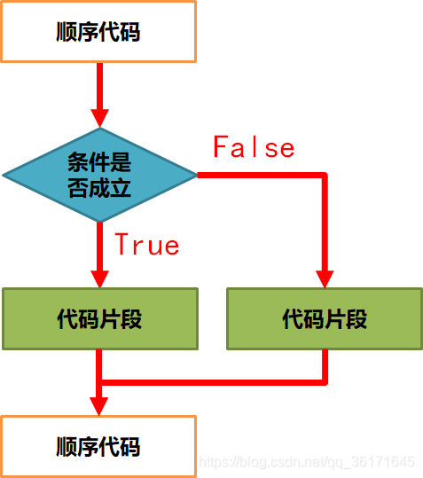

一个常见的if……else语句，常常以下面的语法格式存在：

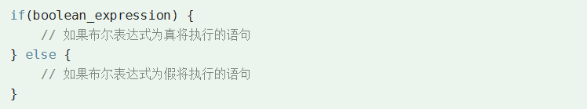

上述boolean_espression可以看做是一个判断后的返回值，如果这个判断是正确的话，那么会执行if{}里面的代码，如果判断是错误的话，那么则会运行else{}里面的代码。

```r
x <- c(1,2,3)

if(4 %in% x) {
  print("包含 4")
} else {
  print("不包含 4")
}
```

```
## [1] "不包含 4"
```

### R循环

有的时候，我们可能需要执行多次代码。在编程语言中，我们可以通过**循环语句**来多次执行一个语句或者语句组，下面是大多数编程语言中循环语句的流程图，常见有while和for循环两种。

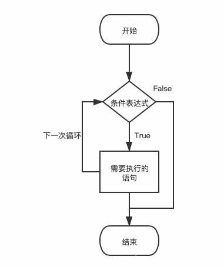

而常见的while循环的循环方式，常常以以下方式执行

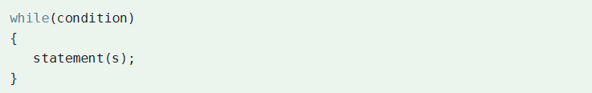

上述condition表示了一个判断条件，在这个例子中，如果condition判断是真，那么执行后面的语句，否则跳出循环，下面我们来看一个while的例子：

```r
cnt <- 2

while (cnt < 7) {
  print(cnt)
  cnt = cnt + 1
}
```

```
## [1] 2
## [1] 3
## [1] 4
## [1] 5
## [1] 6
```

另外一种循环的方式是for循环，其常常以以下方式执行：

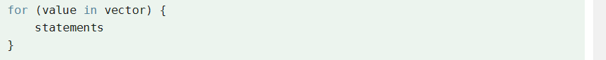

```r
for (i in 1:7){
  print(i)
}
```

```
## [1] 1
## [1] 2
## [1] 3
## [1] 4
## [1] 5
## [1] 6
## [1] 7
```

同样的，我们也可以嵌套循环和条件分支，可见下面的例子：

```r
v <- c(1,2,5,6,7)
for (i in v){
  if (i%%2 == 1){#注意判断是否相等时我们用==，是否不等时用!=
    print(i)
  }else{
    print(i*2)
  }
}
```

```
## [1] 1
## [1] 4
## [1] 5
## [1] 12
## [1] 7
```

### 函数

函数定义通常由以下几个部分组成： - 函数名：为函数指定名称，以便在调用时使用  
- 参数：定义函数接受的输入值。参数是可选的，可以有多个  
- 函数体：实际执行的代码块，用{}括起来  
- 返回值：指定函数的输出结果，使用关键字return

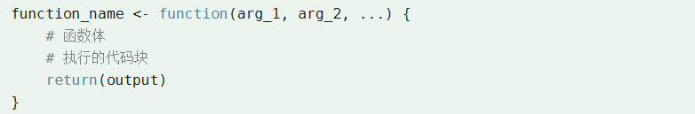

下面请看一个自定义函数的例子：

```r
new.function <- function(a,b,c) {
   result <- a * b + c
   print(result)
}

# 不带参数名
new.function(5,3,11)
```

```
## [1] 26
```

```r
# 带参数名
new.function(a = 11, b = 5, c = 3)
```

```
## [1] 58
```

有关=和<-之间的差异可以看下面两个例子

```r
# 有关= 和 <- 之间的区别，请看下面的例子
?mean
```

```
## 打开httpd帮助服务器… 好了
```

```r
e <- mean(x = c(1,2,3))
```

```r
f <- mean(x <- c(1,2,3))
```